# Midterm

### Bar Plots of Most Dangerous Rides by State (in top 5 States)

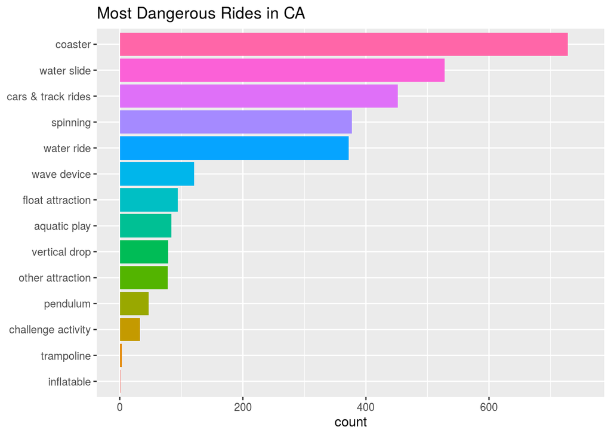

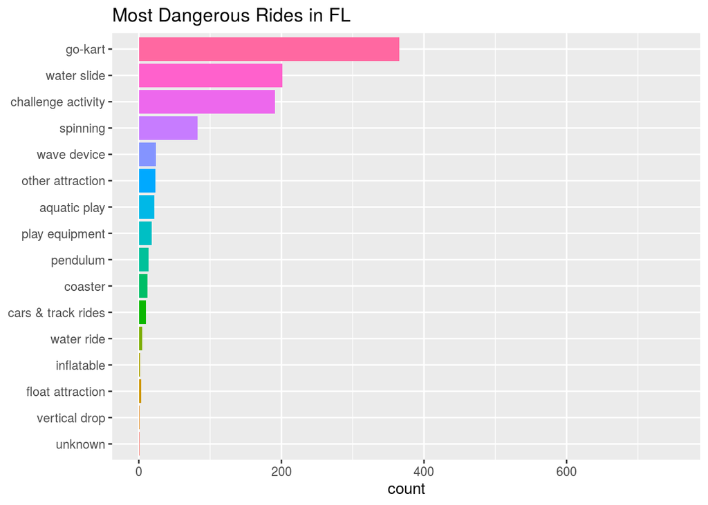

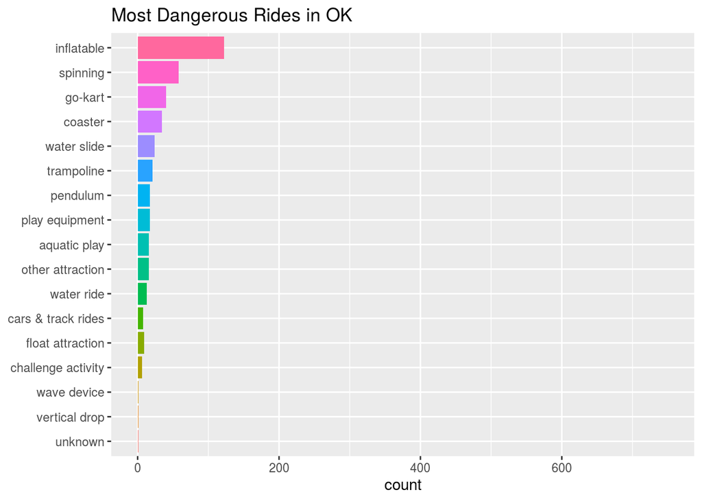

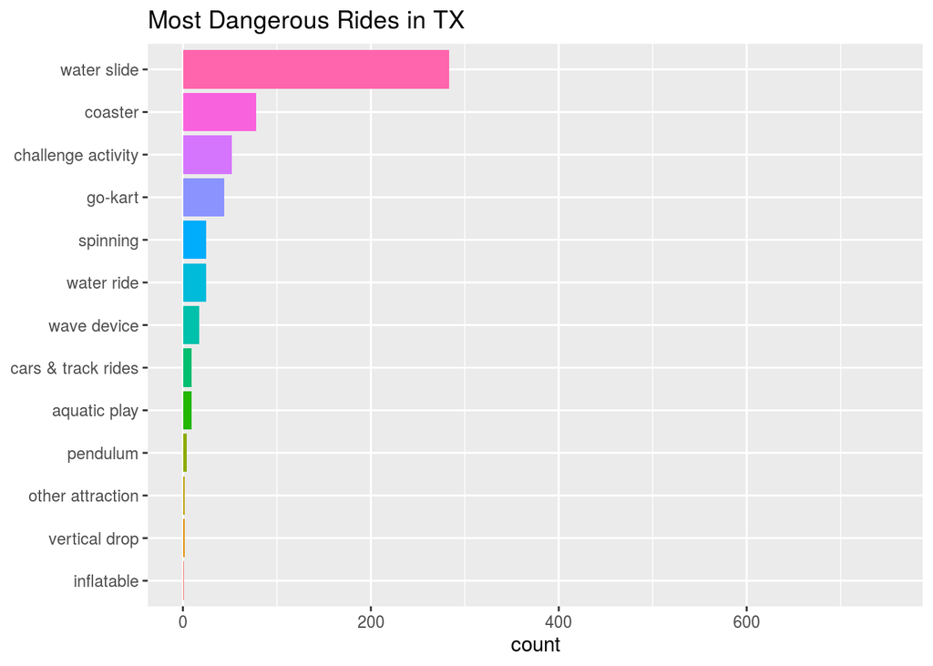

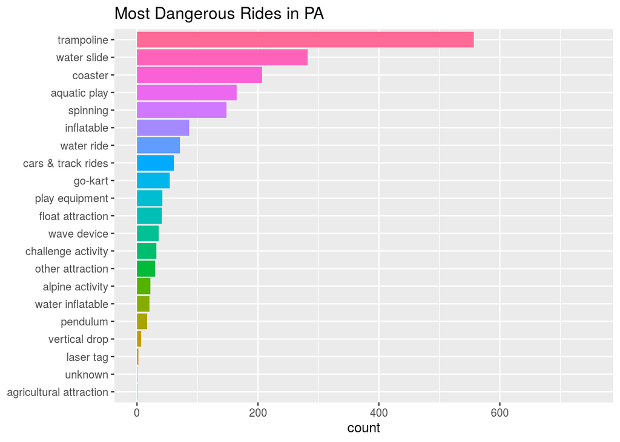

```r
for (state in unique(parks$acc_state_t5)) {
  if (state != "other") {
    parks_sub <- parks[parks$acc_state_t5 == state, ]
    totInj_state <- sum(parks_sub[ , "num_injured"])
    parks_plot_sum <- parks_sub %>% group_by(device_category) %>% summarise(sInj = sum(num_injured), pInj = sInj/totInj_state) %>% arrange(desc(sInj)) %>% ungroup()
    parks_sub$device_category <- factor(parks_sub$device_category, levels = unique(parks_plot_sum$device_category[order(parks_plot_sum$sInj)]))
    print(ggplot(parks_sub) + aes(y = device_category, count = num_injured, fill = device_category) + geom_bar() + xlim(0, 750) + labs(title = paste("Most Dangerous Rides in", state), y = NULL) + theme(legend.position = "none"))
    }
}
```

```r
rm(state)
rm(parks_sub)
rm(totInj_state)
rm(parks_plot_sum)
```

The California bar plot shows that there are less types devices that cause injuries; there are a few device types that have a high injury count and the rest are much lower.

The Florida bar plot shows that most of the data is below 50% of the max injuries (California reaches the max above 700 for coasters). Additionally, the injury count is surprisingly low in Florida.

Similar to California, the Texas bar plot shows that there a limited number of device types that cause injuries. Also, the plot shows just how many more injuries occur in water parks in Texas.

Lastly, the Pennsylvania plot shows why Pennsylvania made it into the top 5 states, mostly due to the number of trampoline injuries.

### Heat Map of the Top 5 States versus Device Type

```r
parks_summary <- parks[parks$acc_state_t5 != "other", ] %>% group_by(acc_state_t5, device_category) %>% summarise(sInj = sum(num_injured)) %>% ungroup
```

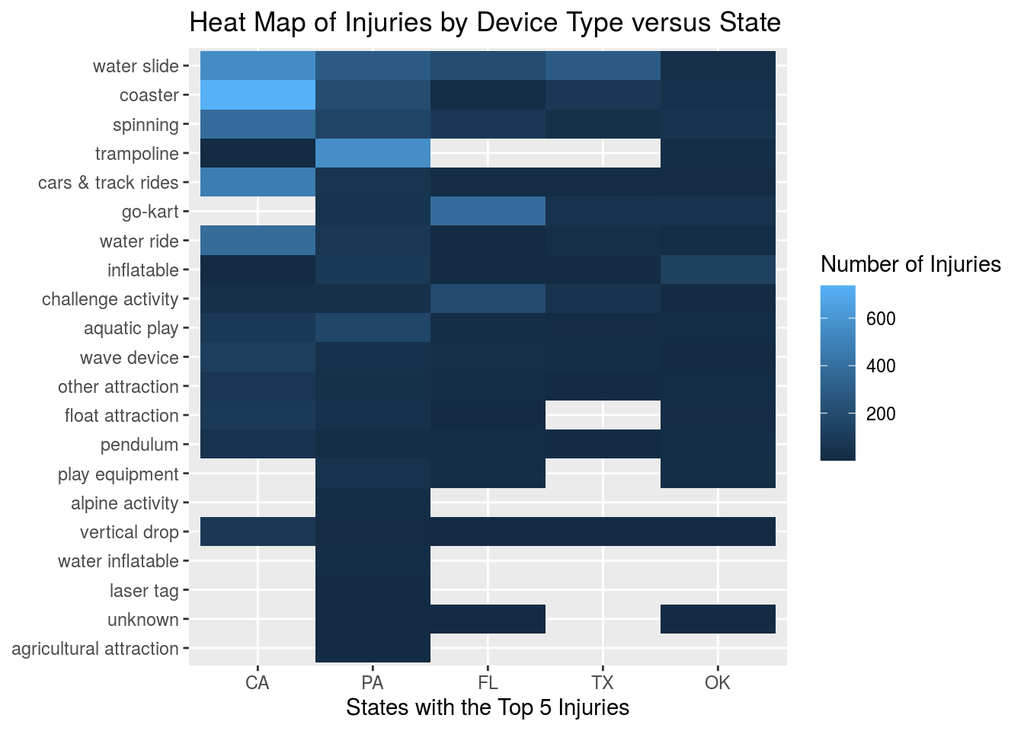

```r
ggplot(parks_summary) + aes(y = device_category, x = acc_state_t5, fill = sInj) + geom_tile() + labs(title = "Heat Map of Injuries by Device Type versus State", y = NULL, x = "States with the Top 5 Injuries", fill = "Number of Injuries")
```

# Final Summary (10 points)

I expected some of the initial analysis of number of injuries by device type, I thought water slides would be the most dangerous. But, I did not expect the difference by the states. I expected that Florida would have a high number of injuries with all of the theme parks there I expected more water related rides, coaster and big amusement park rides, and challenge course rides. I was shocked go-karts was the highest number of injuries in Florida. (I also thought Florida was just more crazy and would have more injuries, I joked about that with Ted at our one on one to go over the data.) I did not expect California to have so many more injuries than Florida, seeing as how the theme parks in California are smaller than Florida. I did expect that water rides and coaster rides would rank high in California. I was very surprised that Pennsylvania had the second most injuries; also that that was a high number of trampoline injuries in PA. I thought Texas could be close to having a top ranking injuries, but I was moderately surprised that water slides was the largest injury source. Lastly, I was surprised that Oklahoma made it in the top 5 number of injuries per state. But, even more surprised that Oklahoma had so many more device categories as compared to theme park travel destinations like California, Florida, and Texas.